# Przepracowani i biedni - zależność między godzinami pracy a bogactwem narodu

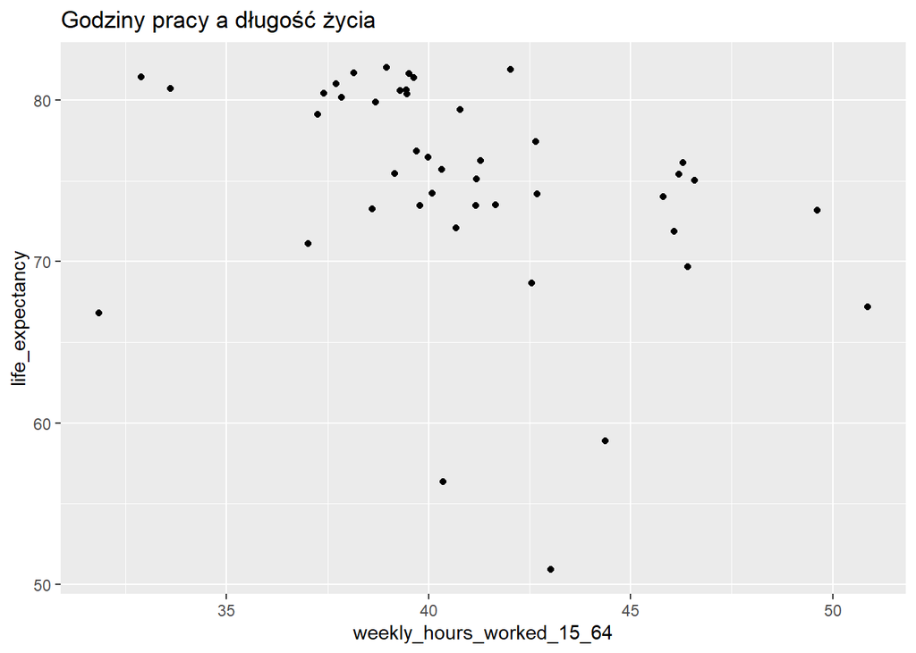

```r
ggplot(data_no_countries, aes(weekly_hours_worked_15_64, life_expectancy)) +
  geom_point() +
  ggtitle('Godziny pracy a długość życia')
```

Mocno rozsiane dane wizualnie potwierdzają umiarkowane korelacje do długości pracy. Jednak na żadnym wykresie nie widać mocnego trendu.

```r
simple_model <- lm(formula = weekly_hours_worked_15_64 ~ gdp_per_capita, data = data_no_countries)
summary(simple_model) # najlepszy R2
```

```
##
## Call:
## lm(formula = weekly_hours_worked_15_64 ~ gdp_per_capita, data = data_no_countries)
##
## Residuals:
##      Min       1Q   Median       3Q      Max
## -10.7003  -1.5909  -0.5559   2.0552   8.4726
##
## Coefficients:
##                  Estimate Std. Error t value Pr(>|t|)
## (Intercept)     4.259e+01  7.243e-01  58.797   <2e-16 ***
## gdp_per_capita -7.740e-05  2.228e-05  -3.474   0.0012 **
## ---
## Signif. codes:  0 '***' 0.001 '**' 0.01 '*' 0.05 '.' 0.1 ' ' 1
##
## Residual standard error: 3.527 on 42 degrees of freedom
## Multiple R-squared:  0.2232, Adjusted R-squared:  0.2047
## F-statistic: 12.07 on 1 and 42 DF,  p-value: 0.001202
```

```r
simple_model_2 <- lm(formula = weekly_hours_worked_15_64 ~ life_expectancy, data = data_no_countries)
summary(simple_model_2)
```

```
##
## Call:
## lm(formula = weekly_hours_worked_15_64 ~ life_expectancy, data = data_no_countries)
##
## Residuals:
##      Min       1Q   Median       3Q      Max
## -10.6180  -1.7043  -0.3593   1.0085   8.4691
##
## Coefficients:
##                 Estimate Std. Error t value Pr(>|t|)
## (Intercept)     55.54477    6.35174   8.745 5.25e-11 ***
## life_expectancy -0.19585    0.08448  -2.318   0.0254 *
## ---
## Signif. codes:  0 '***' 0.001 '**' 0.01 '*' 0.05 '.' 0.1 ' ' 1
##
## Residual standard error: 3.768 on 42 degrees of freedom
## Multiple R-squared:  0.1135, Adjusted R-squared:  0.09235
## F-statistic: 5.375 on 1 and 42 DF,  p-value: 0.02537
```

```r
simple_model_3 <- lm(formula = weekly_hours_worked_15_64 ~ gdp_per_capita_ppp, data = data_no_countries)
summary(simple_model_3)
```

```
##
## Call:
## lm(formula = weekly_hours_worked_15_64 ~ gdp_per_capita_ppp,
##     data = data_no_countries)
##
## Residuals:
##      Min       1Q   Median       3Q      Max
## -11.2697  -1.6312  -0.4451   2.2692   8.3056
##
## Coefficients:
##                      Estimate Std. Error t value Pr(>|t|)
## (Intercept)         4.333e+01  9.227e-01  46.963  < 2e-16 ***
## gdp_per_capita_ppp -1.039e-04  3.171e-05  -3.276  0.00211 **
## ---
## Signif. codes:  0 '***' 0.001 '**' 0.01 '*' 0.05 '.' 0.1 ' ' 1
##
## Residual standard error: 3.571 on 42 degrees of freedom
## Multiple R-squared:  0.2036, Adjusted R-squared:  0.1846
## F-statistic: 10.73 on 1 and 42 DF,  p-value: 0.002113
```

```r
complex_model <- lm(formula = weekly_hours_worked_15_64 ~ gdp_per_capita_ppp + enrollment_tetriary + income_inequality, data = data_no_countries)
summary(complex_model)
```

```
##
## Call:
## lm(formula = weekly_hours_worked_15_64 ~ gdp_per_capita_ppp +
##     enrollment_tetriary + income_inequality, data = data_no_countries)
##
## Residuals:
##      Min       1Q   Median       3Q      Max
## -11.5114  -1.5287  -0.2166   2.0371   8.4399
##
## Coefficients:
##                       Estimate Std. Error t value Pr(>|t|)
## (Intercept)          4.355e+01  3.897e+00  11.174 7.14e-14 ***
## gdp_per_capita_ppp  -9.741e-05  3.812e-05  -2.555   0.0145 *
## enrollment_tetriary -9.680e-03  2.688e-02  -0.360   0.7207
## income_inequality    4.446e-03  7.697e-02   0.058   0.9542
## ---
## Signif. codes:  0 '***' 0.001 '**' 0.01 '*' 0.05 '.' 0.1 ' ' 1
##
## Residual standard error: 3.651 on 40 degrees of freedom
## Multiple R-squared:  0.207,  Adjusted R-squared:  0.1475
## F-statistic:  3.48 on 3 and 40 DF,  p-value: 0.02454
```

Żaden model nie ma wysokiego R-squared, co znaczy, że wariancja PKB nie tłumaczy wariancji working hours jednakże lepiej się spisuje niż model złożony z 3 parametrów (PKB PPP, uczęszczania na uczelnie i Giniego). Do tego w prostym modelu nasza jedyna zmienna ma niższe p-value.

# Wniosek

Moje dane w umiarkowanym stopniu potwierdziły korelację bogactwa kraju i ilości godzin przepracowanych (bogatszy kraj = mniej godzin). Jednak żadne dane nie mogły w wystarczającym stopniu wytłumaczyć wariancji

# Zastrzeżenia